# *STEPHEN RENALDO SETIADI*

## **S4665076**

## ———————————————————————

# ASSESSMENT 2

```r
library(tidyverse)
library(tidymodels)
library(modeldata)
library(skimr)
library(kableExtra)
library(lubridate)
```

# Part 1: formatting RMarkdown document (2 marks)

1. Create an Rmarkdown document with webpage as output (same as in setup)

At the start of the output document include your name in italic font and your student id in bold font as level 2 heading

Separate with a solid line

Include the title “Assignment 2” as level 1 heading

Separate with a solid line

List all tasks in the assignment as headings of the third level and include your results (=output) below each task showing your R code.

https://github.com/rfordatascience/tidytuesday/tree/master/data/2018/2018-11-20

Tasks:

See the definition of variables in a separate section “Data dictionary”

To import the data use

```r
thanks_meal <-read.csv("https://raw.githubusercontent.com/rfordatascience/tidytuesday/master/data/2018/2018-11-20/thanksgiving_meals.csv"
)
```

# Part 2: Data Wrangling and visualization 38 marks

For all tables below, you need to use the RMarkdown functionality to present tables (`kable`).

### 1. Display the first 10 rows of the dataset using `kable()` function (1 marks).

```r
kable(thanks_meal[1:10, ],)%>%
    kable_styling(bootstrap_options = "striped", full_width = F, position = "left")
```

| id | celebrate | main_dish | main_dish_other | main_prep | main_prep_other | stuffing | stuffing_other | cranberry | cranberry_other | gravy | side1 | side2 | side3 | side4 | side5 | side6 | side7 | side8 | side9 | side10 | side11 | side12 | side13 | side14 | side15 | pie1 | pie2 | pie3 | pie4 | … |
| --- | --- | --- | --- | --- | --- | --- | --- | --- | --- | --- | --- | --- | --- | --- | --- | --- | --- | --- | --- | --- | --- | --- | --- | --- | --- | --- | --- | --- | --- | --- |
| 4337954960 | Yes | Turkey | NA | Baked | NA | Bread-based | NA | None | NA | Yes | NA | Carrots | NA | NA | NA | NA | Green beans/green bean casserole | Macaroni and cheese | Mashed potatoes | NA | NA | NA | Yams/sweet potato casserole | NA | NA | Apple | NA | NA | NA | … |
| 4337951949 | Yes | Turkey | NA | Baked | NA | Bread-based | NA | Other (please specify) | Homemade cranberry gelatin ring | Yes | NA | NA | NA | Corn | NA | NA | Green beans/green bean casserole | Macaroni and cheese | Mashed potatoes | Rolls/biscuits | NA | Vegetable salad | Yams/sweet potato casserole | Other (please specify) | Asian vinagrette salad | Apple | NA | NA | Chocolate | … |
| 4337935621 | Yes | Turkey | NA | Roasted | NA | Rice-based | NA | Homemade | NA | Yes | Brussel sprouts | Carrots | Cauliflower | Corn | Cornbread | NA | NA | NA | Mashed potatoes | Rolls/biscuits | NA | Vegetable salad | NA | NA | NA | Apple | NA | Cherry | NA | … |
| 4337933040 | Yes | Turkey | NA | Baked | NA | Bread-based | NA | Homemade | NA | Yes | Brussel sprouts | NA | NA | NA | Cornbread | NA | NA | NA | Mashed potatoes | Rolls/biscuits | NA | Vegetable salad | Yams/sweet potato casserole | NA | NA | NA | NA | NA | NA | … |
| 4337931983 | Yes | Tofurkey | NA | Baked | NA | Bread-based | NA | Canned | NA | Yes | Brussel sprouts | NA | NA | NA | Cornbread | NA | NA | NA | Mashed potatoes | Rolls/biscuits | Squash | Vegetable salad | Yams/sweet potato casserole | NA | NA | Apple | NA | NA | NA | … |
| 4337929779 | Yes | Turkey | NA | Roasted | NA | Rice-based | NA | Homemade | NA | Yes | Brussel sprouts | Carrots | Cauliflower | Corn | Cornbread | Fruit salad | Green beans/green bean casserole | Macaroni and cheese | Mashed potatoes | Rolls/biscuits | Squash | Vegetable salad | Yams/sweet potato casserole | NA | NA | NA | NA | NA | NA | … |
| 4337924420 | Yes | Turkey | NA | Baked | NA | Bread-based | NA | Canned | NA | Yes | NA | NA | NA | NA | NA | Fruit salad | Green beans/green bean casserole | NA | Mashed potatoes | Rolls/biscuits | NA | NA | Yams/sweet potato casserole | NA | NA | Apple | NA | NA | NA | … |
| 4337916002 | Yes | Turkey | NA | Baked | NA | Rice-based | NA | Homemade | NA | Yes | NA | Carrots | NA | NA | NA | NA | NA | NA | NA | NA | NA | NA | NA | NA | NA | NA | NA | NA | Chocolate | … |
| 4337914977 | Yes | Turkey | NA | Roasted | NA | Bread-based | NA | Canned | NA | Yes | Brussel sprouts | NA | NA | Corn | Cornbread | NA | Green beans/green bean casserole | NA | Mashed potatoes | Rolls/biscuits | Squash | NA | NA | NA | NA | Apple | Buttermilk | NA | NA | … |
| 4337899817 | Yes | Other (please specify) | Turkey and Ham | Baked | NA | Bread-based | NA | Other (please specify) | Both Canned and Homemade | Yes | Brussel sprouts | Carrots | NA | NA | NA | NA | Green beans/green bean casserole | NA | Mashed potatoes | Rolls/biscuits | NA | NA | Yams/sweet potato casserole | NA | NA | NA | Buttermilk | NA | NA | … |

### 2. Using `skim()` display the summary of variables.

Think about the task to predict a family income based on their menu: what variables may be useful? Are all of them correct type? Write 2-3 sentences with your explanation. (2 marks)

Answer: To predict a family income based on their menu we can use a variabel such as “Age variable”, “gender variable” to create the analysis output of the family income/

Think about the task to predict a community type or US_region based on their menu: what variables may be useful? Are all of them correct type? (2 marks)

Answer: To predit a community type or Us_region we can we can use the variable “watch program variable” and “main_dish”

```r
skim(thanks_meal)
```

Data summary

| Name | thanks_meal |
| --- | --- |
| Number of rows | 1058 |
| Number of columns | 65 |
| _______________________ |  |
| Column type frequency: |  |
| character | 64 |
| numeric | 1 |
| ________________________ |  |
| Group variables | None |

**Variable type: character**

| skim_variable | n_missing | complete_rate | min | max | empty | n_unique | whitespace |
| --- | --- | --- | --- | --- | --- | --- | --- |
| celebrate | 0 | 1.00 | 2 | 3 | 0 | 2 | 0 |
| main_dish | 84 | 0.92 | 6 | 22 | 0 | 8 | 0 |
| main_dish_other | 1023 | 0.03 | 4 | 85 | 0 | 32 | 0 |
| main_prep | 84 | 0.92 | 5 | 22 | 0 | 5 | 0 |
| main_prep_other | 1007 | 0.05 | 1 | 33 | 0 | 32 | 0 |
| stuffing | 84 | 0.92 | 4 | 22 | 0 | 4 | 0 |
| stuffing_other | 1022 | 0.03 | 4 | 46 | 0 | 29 | 0 |
| cranberry | 84 | 0.92 | 4 | 22 | 0 | 4 | 0 |
| cranberry_other | 1033 | 0.02 | 3 | 61 | 0 | 24 | 0 |
| gravy | 84 | 0.92 | 2 | 3 | 0 | 2 | 0 |
| side1 | 903 | 0.15 | 15 | 15 | 0 | 1 | 0 |
| side2 | 816 | 0.23 | 7 | 7 | 0 | 1 | 0 |
| side3 | 970 | 0.08 | 11 | 11 | 0 | 1 | 0 |
| side4 | 594 | 0.44 | 4 | 4 | 0 | 1 | 0 |
| side5 | 823 | 0.22 | 9 | 9 | 0 | 1 | 0 |
| side6 | 843 | 0.20 | 11 | 11 | 0 | 1 | 0 |
| side7 | 372 | 0.65 | 32 | 32 | 0 | 1 | 0 |
| side8 | 852 | 0.19 | 19 | 19 | 0 | 1 | 0 |
| side9 | 241 | 0.77 | 15 | 15 | 0 | 1 | 0 |
| side10 | 292 | 0.72 | 14 | 14 | 0 | 1 | 0 |
| side11 | 887 | 0.16 | 6 | 6 | 0 | 1 | 0 |
| side12 | 849 | 0.20 | 15 | 15 | 0 | 1 | 0 |
| side13 | 427 | 0.60 | 27 | 27 | 0 | 1 | 0 |
| side14 | 947 | 0.10 | 22 | 22 | 0 | 1 | 0 |
| side15 | 947 | 0.10 | 4 | 78 | 0 | 89 | 0 |
| pie1 | 544 | 0.49 | 5 | 5 | 0 | 1 | 0 |
| pie2 | 1023 | 0.03 | 10 | 10 | 0 | 1 | 0 |
| pie3 | 945 | 0.11 | 6 | 6 | 0 | 1 | 0 |
| pie4 | 925 | 0.13 | 9 | 9 | 0 | 1 | 0 |
| pie5 | 1022 | 0.03 | 13 | 13 | 0 | 1 | 0 |
| pie6 | 1019 | 0.04 | 8 | 8 | 0 | 1 | 0 |
| pie7 | 1024 | 0.03 | 5 | 5 | 0 | 1 | 0 |
| pie8 | 716 | 0.32 | 5 | 5 | 0 | 1 | 0 |
| pie9 | 329 | 0.69 | 7 | 7 | 0 | 1 | 0 |
| pie10 | 906 | 0.14 | 12 | 12 | 0 | 1 | 0 |
| pie11 | 1018 | 0.04 | 4 | 4 | 0 | 1 | 0 |
| pie12 | 987 | 0.07 | 22 | 22 | 0 | 1 | 0 |
| pie13 | 987 | 0.07 | 5 | 46 | 0 | 61 | 0 |
| dessert1 | 948 | 0.10 | 13 | 13 | 0 | 1 | 0 |
| dessert2 | 1042 | 0.02 | 8 | 8 | 0 | 1 | 0 |
| dessert3 | 930 | 0.12 | 8 | 8 | 0 | 1 | 0 |
| dessert4 | 986 | 0.07 | 11 | 11 | 0 | 1 | 0 |
| dessert5 | 867 | 0.18 | 10 | 10 | 0 | 1 | 0 |
| dessert6 | 854 | 0.19 | 7 | 7 | 0 | 1 | 0 |
| dessert7 | 1015 | 0.04 | 5 | 5 | 0 | 1 | 0 |
| dessert8 | 792 | 0.25 | 9 | 9 | 0 | 1 | 0 |
| dessert9 | 955 | 0.10 | 13 | 13 | 0 | 1 | 0 |
| dessert10 | 763 | 0.28 | 4 | 4 | 0 | 1 | 0 |
| dessert11 | 924 | 0.13 | 22 | 22 | 0 | 1 | 0 |
| dessert12 | 924 | 0.13 | 3 | 59 | 0 | 92 | 0 |
| prayer | 99 | 0.91 | 2 | 3 | 0 | 2 | 0 |
| travel | 107 | 0.90 | 59 | 80 | 0 | 4 | 0 |
| watch_program | 556 | 0.47 | 13 | 13 | 0 | 1 | 0 |
| kids_table_age | 107 | 0.90 | 2 | 13 | 0 | 12 | 0 |
| hometown_friends | 107 | 0.90 | 2 | 3 | 0 | 2 | 0 |
| friendsgiving | 107 | 0.90 | 2 | 3 | 0 | 2 | 0 |
| black_friday | 107 | 0.90 | 2 | 3 | 0 | 2 | 0 |
| work_retail | 107 | 0.90 | 2 | 3 | 0 | 2 | 0 |
| work_black_friday | 988 | 0.07 | 2 | 13 | 0 | 3 | 0 |
| community_type | 110 | 0.90 | 5 | 8 | 0 | 3 | 0 |
| age | 33 | 0.97 | 3 | 7 | 0 | 4 | 0 |
| gender | 33 | 0.97 | 4 | 6 | 0 | 2 | 0 |
| family_income | 33 | 0.97 | 12 | 20 | 0 | 11 | 0 |
| us_region | 59 | 0.94 | 7 | 18 | 0 | 9 | 0 |

**Variable type: numeric**

| skim_variable | n_missing | complete_rate | mean | sd | p0 | p25 | p50 | p75 | p100 | hist |
| --- | --- | --- | --- | --- | --- | --- | --- | --- | --- | --- |
| id | 0 | 1 | 4336731188 | 493783.4 | 4335894916 | 4336339486 | 4336796628 | 4337012140 | 4337954960 | ▅▃▇▂▂ |

```r
sapply(thanks_meal, class)
```

```
##                id         celebrate         main_dish   main_dish_other
##         "numeric"       "character"       "character"       "character"
##         main_prep   main_prep_other          stuffing    stuffing_other
##       "character"       "character"       "character"       "character"
##         cranberry   cranberry_other             gravy             side1
##       "character"       "character"       "character"       "character"
##             side2             side3             side4             side5
##       "character"       "character"       "character"       "character"
##             side6             side7             side8             side9
##       "character"       "character"       "character"       "character"
##            side10            side11            side12            side13
##       "character"       "character"       "character"       "character"
##            side14            side15              pie1              pie2
##       "character"       "character"       "character"       "character"
##              pie3              pie4              pie5              pie6
##       "character"       "character"       "character"       "character"
##              pie7              pie8              pie9             pie10
##       "character"       "character"       "character"       "character"
##             pie11             pie12             pie13          dessert1
##       "character"       "character"       "character"       "character"
##          dessert2          dessert3          dessert4          dessert5
##       "character"       "character"       "character"       "character"
##          dessert6          dessert7          dessert8          dessert9
##       "character"       "character"       "character"       "character"
##         dessert10         dessert11         dessert12            prayer
##       "character"       "character"       "character"       "character"
##            travel     watch_program    kids_table_age  hometown_friends
##       "character"       "character"       "character"       "character"
##     friendsgiving      black_friday       work_retail work_black_friday
##       "character"       "character"       "character"       "character"
##    community_type               age            gender     family_income
##       "character"       "character"       "character"       "character"
##         us_region
##       "character"
```

### 3. Use `fct_reorder` and `parse_number` functions to create a factor variable `family_income`(2 mark).

```r
thanks_meal_parse<-thanks_meal %>%
  mutate(family_income = fct_relevel(fct_reorder(family_income, parse_number(age)),"Prefer not to answer"))
```

```r
skim(thanks_meal_parse)
```

Data summary

| Name | thanks_meal_parse |
| --- | --- |
| Number of rows | 1058 |
| Number of columns | 65 |
| _______________________ |  |
| Column type frequency: |  |
| character | 63 |
| factor | 1 |
| numeric | 1 |
| ________________________ |  |
| Group variables | None |

**Variable type: character**

| skim_variable | n_missing | complete_rate | min | max | empty | n_unique | whitespace |
| --- | --- | --- | --- | --- | --- | --- | --- |
| celebrate | 0 | 1.00 | 2 | 3 | 0 | 2 | 0 |
| main_dish | 84 | 0.92 | 6 | 22 | 0 | 8 | 0 |
| main_dish_other | 1023 | 0.03 | 4 | 85 | 0 | 32 | 0 |
| main_prep | 84 | 0.92 | 5 | 22 | 0 | 5 | 0 |
| main_prep_other | 1007 | 0.05 | 1 | 33 | 0 | 32 | 0 |
| stuffing | 84 | 0.92 | 4 | 22 | 0 | 4 | 0 |
| stuffing_other | 1022 | 0.03 | 4 | 46 | 0 | 29 | 0 |
| cranberry | 84 | 0.92 | 4 | 22 | 0 | 4 | 0 |
| cranberry_other | 1033 | 0.02 | 3 | 61 | 0 | 24 | 0 |
| gravy | 84 | 0.92 | 2 | 3 | 0 | 2 | 0 |
| side1 | 903 | 0.15 | 15 | 15 | 0 | 1 | 0 |
| side2 | 816 | 0.23 | 7 | 7 | 0 | 1 | 0 |
| side3 | 970 | 0.08 | 11 | 11 | 0 | 1 | 0 |
| side4 | 594 | 0.44 | 4 | 4 | 0 | 1 | 0 |
| side5 | 823 | 0.22 | 9 | 9 | 0 | 1 | 0 |
| side6 | 843 | 0.20 | 11 | 11 | 0 | 1 | 0 |
| side7 | 372 | 0.65 | 32 | 32 | 0 | 1 | 0 |
| side8 | 852 | 0.19 | 19 | 19 | 0 | 1 | 0 |
| side9 | 241 | 0.77 | 15 | 15 | 0 | 1 | 0 |
| side10 | 292 | 0.72 | 14 | 14 | 0 | 1 | 0 |
| side11 | 887 | 0.16 | 6 | 6 | 0 | 1 | 0 |
| side12 | 849 | 0.20 | 15 | 15 | 0 | 1 | 0 |
| side13 | 427 | 0.60 | 27 | 27 | 0 | 1 | 0 |
| side14 | 947 | 0.10 | 22 | 22 | 0 | 1 | 0 |
| side15 | 947 | 0.10 | 4 | 78 | 0 | 89 | 0 |
| pie1 | 544 | 0.49 | 5 | 5 | 0 | 1 | 0 |
| pie2 | 1023 | 0.03 | 10 | 10 | 0 | 1 | 0 |
| pie3 | 945 | 0.11 | 6 | 6 | 0 | 1 | 0 |
| pie4 | 925 | 0.13 | 9 | 9 | 0 | 1 | 0 |
| pie5 | 1022 | 0.03 | 13 | 13 | 0 | 1 | 0 |
| pie6 | 1019 | 0.04 | 8 | 8 | 0 | 1 | 0 |
| pie7 | 1024 | 0.03 | 5 | 5 | 0 | 1 | 0 |
| pie8 | 716 | 0.32 | 5 | 5 | 0 | 1 | 0 |
| pie9 | 329 | 0.69 | 7 | 7 | 0 | 1 | 0 |
| pie10 | 906 | 0.14 | 12 | 12 | 0 | 1 | 0 |
| pie11 | 1018 | 0.04 | 4 | 4 | 0 | 1 | 0 |
| pie12 | 987 | 0.07 | 22 | 22 | 0 | 1 | 0 |
| pie13 | 987 | 0.07 | 5 | 46 | 0 | 61 | 0 |
| dessert1 | 948 | 0.10 | 13 | 13 | 0 | 1 | 0 |
| dessert2 | 1042 | 0.02 | 8 | 8 | 0 | 1 | 0 |
| dessert3 | 930 | 0.12 | 8 | 8 | 0 | 1 | 0 |
| dessert4 | 986 | 0.07 | 11 | 11 | 0 | 1 | 0 |
| dessert5 | 867 | 0.18 | 10 | 10 | 0 | 1 | 0 |
| dessert6 | 854 | 0.19 | 7 | 7 | 0 | 1 | 0 |
| dessert7 | 1015 | 0.04 | 5 | 5 | 0 | 1 | 0 |
| dessert8 | 792 | 0.25 | 9 | 9 | 0 | 1 | 0 |
| dessert9 | 955 | 0.10 | 13 | 13 | 0 | 1 | 0 |
| dessert10 | 763 | 0.28 | 4 | 4 | 0 | 1 | 0 |
| dessert11 | 924 | 0.13 | 22 | 22 | 0 | 1 | 0 |
| dessert12 | 924 | 0.13 | 3 | 59 | 0 | 92 | 0 |
| prayer | 99 | 0.91 | 2 | 3 | 0 | 2 | 0 |
| travel | 107 | 0.90 | 59 | 80 | 0 | 4 | 0 |
| watch_program | 556 | 0.47 | 13 | 13 | 0 | 1 | 0 |
| kids_table_age | 107 | 0.90 | 2 | 13 | 0 | 12 | 0 |
| hometown_friends | 107 | 0.90 | 2 | 3 | 0 | 2 | 0 |
| friendsgiving | 107 | 0.90 | 2 | 3 | 0 | 2 | 0 |
| black_friday | 107 | 0.90 | 2 | 3 | 0 | 2 | 0 |
| work_retail | 107 | 0.90 | 2 | 3 | 0 | 2 | 0 |
| work_black_friday | 988 | 0.07 | 2 | 13 | 0 | 3 | 0 |
| community_type | 110 | 0.90 | 5 | 8 | 0 | 3 | 0 |
| age | 33 | 0.97 | 3 | 7 | 0 | 4 | 0 |
| gender | 33 | 0.97 | 4 | 6 | 0 | 2 | 0 |
| us_region | 59 | 0.94 | 7 | 18 | 0 | 9 | 0 |

**Variable type: factor**

| skim_variable | n_missing | complete_rate | ordered | n_unique | top_counts |
| --- | --- | --- | --- | --- | --- |
| family_income | 33 | 0.97 | FALSE | 11 | $25: 180, Pre: 136, $50: 135, $75: 133 |

**Variable type: numeric**

| skim_variable | n_missing | complete_rate | mean | sd | p0 | p25 | p50 | p75 | p100 | hist |
| --- | --- | --- | --- | --- | --- | --- | --- | --- | --- | --- |
| id | 0 | 1 | 4336731188 | 493783.4 | 4335894916 | 4336339486 | 4336796628 | 4337012140 | 4337954960 | ▅▃▇▂▂ |

### 4. What is the number of people who celebrate? (1 mark)

Answer : The number of people who celebrate is 980

```r
thanks_meal_parse%>%
count(celebrate, sort = TRUE, name = "People")%>%
  filter(celebrate!= "No")
```

```
##   celebrate People
## 1       Yes    980
```

### 5. What are categories and insights for each main dish served and the method it is prepared? (2 marks)

```r
thanks_meal_parse%>%
  count(main_dish, main_prep, sort = TRUE, name = "Total") %>%
  filter(main_dish!= "I don't know",main_dish!=  "Other (please specify)", main_prep!= "I don't know",main_prep!= "Other (please specify)")%>%
  drop_na(main_dish, main_prep)%>%
  kable("pipe")
```

| main_dish | main_prep | Total |
| --- | --- | --- |
| Turkey | Baked | 422 |
| Turkey | Roasted | 351 |
| Turkey | Fried | 41 |
| Ham/Pork | Baked | 22 |
| Tofurkey | Baked | 14 |
| Ham/Pork | Roasted | 5 |
| Roast beef | Roasted | 5 |
| Chicken | Baked | 4 |
| Chicken | Roasted | 4 |
| Tofurkey | Roasted | 4 |
| Roast beef | Baked | 3 |
| Turducken | Roasted | 3 |
| Chicken | Fried | 2 |
| Roast beef | Fried | 2 |

### 6. Create 3 different data viz showing insights for main dish served and the method. Provide your own legend and use themes.

Write 2-3 sentences with your explanation of each insight. (4 marks)

```r
data_viz <- thanks_meal_parse%>%
  count(main_dish, main_prep, sort = TRUE, name = "Total") %>%
  filter(main_dish!= "I don't know",main_dish!=  "Other (please specify)", main_prep!= "I don't know",main_prep!= "Other (please specify)")%>%
  drop_na(main_dish, main_prep)
```

```r
data_viz$Total<-as.factor(data_viz$Total)
```

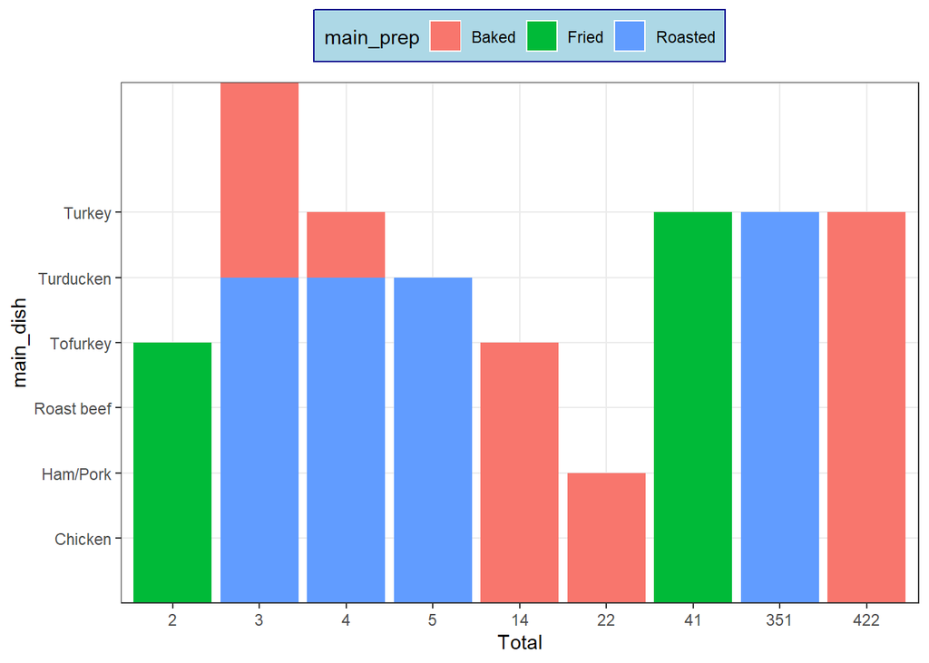

```r
data_viz %>%
  ggplot(aes(Total, main_dish,fill = main_prep))+
  geom_col()+
  theme_bw()+
  theme(legend.position="top")+
  theme(legend.background
        = element_rect(fill="lightblue",size=0.5,
                       linetype="solid", colour ="darkblue"))
```

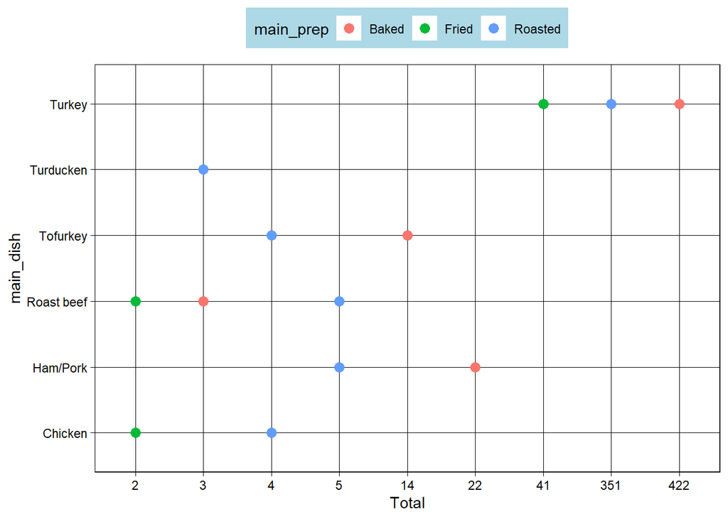

```r
data_viz %>%
  ggplot(mapping =
           aes(x = Total, y = main_dish , color = main_prep))+
  geom_point(size = 3, )+
  theme_linedraw()+
  theme(legend.position="top")+
  theme(legend.background
        = element_rect(fill="lightblue",size=0.5, linetype="solid"))
```

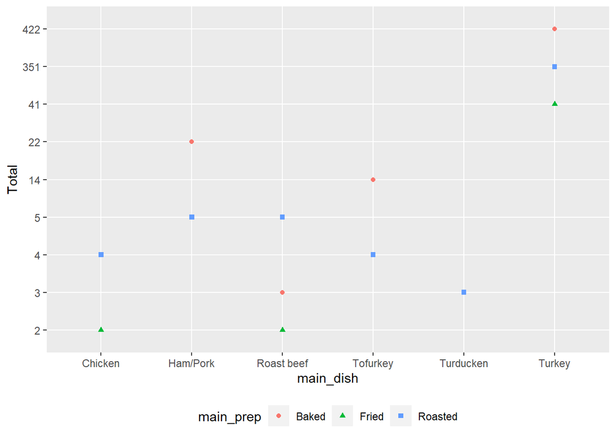

```r
data_viz%>%
  ggplot(aes(main_dish,Total, color=main_prep, shape=main_prep))+
    geom_point()+
  theme(legend.position="bottom", legend.box = "horizontal")
```

### 7. How many use cranberry sauce? How many use gravy? 2marks

Cranbery Sauce = 803, and gravy = 892

```r
thanks_meal_parse%>%
  drop_na(cranberry, gravy)%>%
  count(cranberry, sort = TRUE)%>%
  filter(cranberry!= "None", cranberry!= "Other (please specify)")%>%
  kable("pipe")
```

| cranberry | n |
| --- | --- |
| Canned | 502 |
| Homemade | 301 |

```r
thanks_meal_parse%>%
  drop_na(cranberry, gravy)%>%
  count(gravy, sort = TRUE, name = "Sauce" )%>%
  filter(gravy!= "No")%>%
  kable("pipe")
```

| gravy | Sauce |
| --- | --- |
| Yes | 892 |

### 8-9. What is the distribution of those who celebrate across income ranges. Create a data viz.Write 2-3 sentences with your explanation of each insight. (4 marks)

The distribution across income range

```r
income_range_viz <-thanks_meal_parse%>%
  count(family_income, celebrate, name = "Total", sort = TRUE)%>%
  filter(family_income!= "Prefer not to answer", celebrate!="No")
```

```r
print(income_range_viz)
```

```
##           family_income celebrate Total
## 1    $25,000 to $49,999       Yes   166
## 2    $50,000 to $74,999       Yes   127
## 3    $75,000 to $99,999       Yes   127
## 4  $100,000 to $124,999       Yes   109
## 5       $200,000 and up       Yes    76
## 6    $10,000 to $24,999       Yes    60
## 7          $0 to $9,999       Yes    52
## 8  $125,000 to $149,999       Yes    48
## 9  $150,000 to $174,999       Yes    38
## 10 $175,000 to $199,999       Yes    26
```

There are 10 groups of family income distribution from the smallest range of 52 family with income $0-9,999, and 26 family with income range $175,000 to $199,000 which represent the smallest distribution of income range.

predominantly, there are 166 distribution family income with range $25,000 to $49,000.

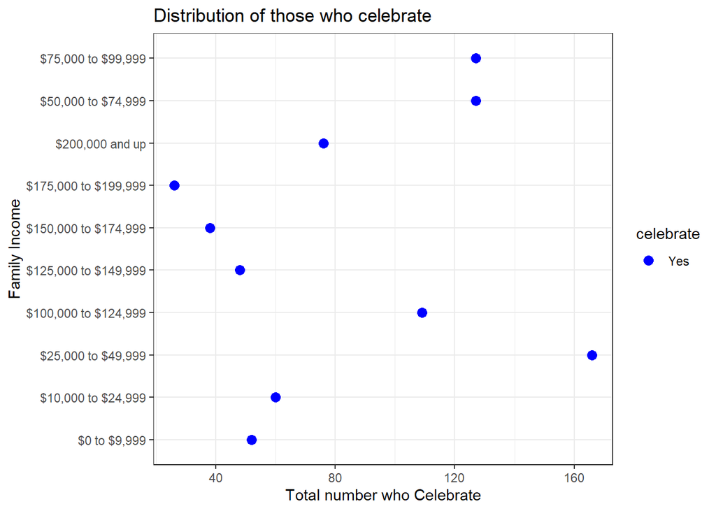

```r
income_range_viz %>%
  ggplot(aes(family_income, Total, fill = celebrate)) +
  geom_point(size =3, colour = "blue") +
  coord_flip()+
  labs(x = "Family Income", y = "Total number who Celebrate",
       title = "Distribution of those who celebrate")+
  theme_bw()
```

### 10. Use the following code to create a new data set 2 mark

select(id, starts_with(“side”), starts_with(“pie”), starts_with(“dessert”)) %>% select(-side15, -pie13, -dessert12) %>% gather(type, value, -id) %>% filter(!is.na(value), !value %in% c(“None”, “Other (please specify)”)) %>% mutate(type = str_remove(type, “\d+”))

Write 2-3 sentences with your explanation of what it does. (4 marks)

```r
thaks_meal_obs <- thanks_meal_parse%>%
select(id, starts_with("side"),
         starts_with("pie"),
         starts_with("dessert")) %>%
  select(-side15, -pie13, -dessert12) %>%
  gather(type, value, -id) %>%
  filter(!is.na(value),
         !value %in% c("None", "Other (please specify)")) %>%
  mutate(type = str_remove(type, "\\d+"))
```

This function are generate a data trasnformation. This function manipulate variable to create a new data set with combining all the variable that starts with (id, ‘side’, ‘pie’ and ‘dessert’) `select(id, starts_with("side"),` `starts_with("pie"),` `starts_with("dessert"))`

removing variables name side15, pie13 and dessert12

`select(-side15, -pie13, -dessert12)``

and also droping “NA” value, “None” value and other Other (please specify) from the selected function `filter(!is.na(value)` `!value %in% c("None", "Other (please specify)"))`

and create a new data frame with new length, size and observation value. with `gather(type, value, -id)`

create a new variable from type that only contain value `mutate(type = str_remove(type, "\\d+"))`

### 11-12. Install package `widyr` and use `pairwise_cor()` function

https://www.rdocumentation.org/packages/widyr/versions/0.1.3/topics/pairwise_cor

Write 2-3 sentences with your explanation of what it does. (2 marks) Use this code for the new dataset ` pairwise_cor(value, id, sort = TRUE)

```r
#install.packages("widyr")
```

This function call pearson’s correlation to get the summary and descriptive statistic and test value of two different variable based on the variable that link them together to perform “Pairwise deletion” (the variable that link or the independent value is “id”) Please see below example

```r
library(widyr)
library(gapminder)
thanks_meal %>%
  filter(!is.na(community_type),
         family_income!= "Prefer not to answer")%>%
  pairwise_cor(age, family_income, id, sort = TRUE)
```

```
## # A tibble: 12 x 3
##    item1   item2   correlation
##    <chr>   <chr>         <dbl>
##  1 30 - 44 18 - 29       0.747
##  2 18 - 29 30 - 44       0.747
##  3 60+     30 - 44       0.405
##  4 30 - 44 60+           0.405
##  5 60+     18 - 29       0.335
##  6 18 - 29 60+           0.335
##  7 45 - 59 30 - 44       0.316
##  8 30 - 44 45 - 59       0.316
##  9 45 - 59 60+           0.119
## 10 60+     45 - 59       0.119
## 11 45 - 59 18 - 29      -0.143
## 12 18 - 29 45 - 59      -0.143
```

Write 1 sentence with your explanation of what insights it shows. (2 marks)

The correlations of pairs of items in a column age and family income based on id column, generate a corellation value

### 13. Use `lm()` or randomForest() function to build a model that predict a family income based on data in the dataset. 8 marks

```r
library(randomForest)
library(modeldata)
library(tidymodels)
library(skimr)
library(stats)
library(caret)
library(readxl)
```

```r
predict_model_data <- thanks_meal_parse %>%
  filter(family_income!= "Prefer not to answer",!is.na(age), !is.na(community_type), !is.na(watch_program),!is.na(us_region) )%>%
  select(id, family_income ,community_type, watch_program, age, us_region)
```

```r
skim(predict_model_data)
```

Data summary

| Name | predict_model_data |
| --- | --- |
| Number of rows | 433 |
| Number of columns | 6 |
| _______________________ |  |
| Column type frequency: |  |
| character | 4 |
| factor | 1 |
| numeric | 1 |
| ________________________ |  |
| Group variables | None |

**Variable type: character**

| skim_variable | n_missing | complete_rate | min | max | empty | n_unique | whitespace |
| --- | --- | --- | --- | --- | --- | --- | --- |
| community_type | 0 | 1 | 5 | 8 | 0 | 3 | 0 |
| watch_program | 0 | 1 | 13 | 13 | 0 | 1 | 0 |
| age | 0 | 1 | 3 | 7 | 0 | 4 | 0 |
| us_region | 0 | 1 | 7 | 18 | 0 | 9 | 0 |

**Variable type: factor**

| skim_variable | n_missing | complete_rate | ordered | n_unique | top_counts |
| --- | --- | --- | --- | --- | --- |
| family_income | 0 | 1 | FALSE | 10 | $25: 86, $50: 67, $75: 65, $10: 61 |

**Variable type: numeric**

| skim_variable | n_missing | complete_rate | mean | sd | p0 | p25 | p50 | p75 | p100 | hist |
| --- | --- | --- | --- | --- | --- | --- | --- | --- | --- | --- |
| id | 0 | 1 | 4336719315 | 466054.3 | 4335943060 | 4336376803 | 4336804174 | 4336998552 | 4337914977 | ▅▃▇▂▁ |

```r
predict_model_data$family_income <- droplevels(predict_model_data$family_income)
```

```r
predict.community.rf <- randomForest(family_income~ community_type,
                           data = predict_model_data,
                           importance=TRUE, proximity=TRUE)
```

```r
print(predict.community.rf)
```

```
##
## Call:
##  randomForest(formula = family_income ~ community_type, data = predict_model_data,      importance = TRUE, proximity = TRUE)
##                Type of random forest: classification
##                      Number of trees: 500
## No. of variables tried at each split: 1
##
##         OOB estimate of  error rate: 84.76%
## Confusion matrix:
##                      $0 to $9,999 $10,000 to $24,999 $25,000 to $49,999
## $0 to $9,999                    0                  0                 20
## $10,000 to $24,999              0                  0                 30
## $25,000 to $49,999              0                  0                 66
## $100,000 to $124,999            0                  0                 57
## $125,000 to $149,999            0                  0                 30
## $150,000 to $174,999            0                  0                 17
## $175,000 to $199,999            0                  0                 12
## $200,000 and up                 0                  0                 36
## $50,000 to $74,999              0                  0                 67
## $75,000 to $99,999              0                  0                 61
##                      $100,000 to $124,999 $125,000 to $149,999
## $0 to $9,999                            0                    0
## $10,000 to $24,999                      0                    0
## $25,000 to $49,999                      0                    0
## $100,000 to $124,999                    0                    0
## $125,000 to $149,999                    0                    0
## $150,000 to $174,999                    0                    0
## $175,000 to $199,999                    0                    0
## $200,000 and up                         0                    0
## $50,000 to $74,999                      0                    0
## $75,000 to $99,999                      1                    0
##                      $150,000 to $174,999 $175,000 to $199,999 $200,000 and up
## $0 to $9,999                            0                    0               0
## $10,000 to $24,999                      0                    0               0
## $25,000 to $49,999                      0                    0               0
## $100,000 to $124,999                    0                    0               0
## $125,000 to $149,999                    0                    0               0
## $150,000 to $174,999                    0                    0               0
## $175,000 to $199,999                    0                    0               0
## $200,000 and up                         0                    0               0
## $50,000 to $74,999                      0                    0               0
## $75,000 to $99,999                      0                    0               0
##                      $50,000 to $74,999 $75,000 to $99,999 class.error
## $0 to $9,999                          2                  0   1.0000000
## $10,000 to $24,999                    0                  0   1.0000000
## $25,000 to $49,999                   20                  0   0.2325581
## $100,000 to $124,999                  4                  0   1.0000000
## $125,000 to $149,999                  2                  0   1.0000000
## $150,000 to $174,999                  1                  0   1.0000000
## $175,000 to $199,999                  2                  0   1.0000000
## $200,000 and up                       2                  0   1.0000000
## $50,000 to $74,999                    0                  0   1.0000000
## $75,000 to $99,999                    3                  0   1.0000000
```

```r
predict.age.rf <- randomForest(family_income~ age,
                           data = predict_model_data,
                           importance=TRUE, proximity=TRUE)
```

```r
print(predict.age.rf)
```

```
##
## Call:
##  randomForest(formula = family_income ~ age, data = predict_model_data,      importance = TRUE, proximity = TRUE)
##                Type of random forest: classification
##                      Number of trees: 500
## No. of variables tried at each split: 1
##
##         OOB estimate of  error rate: 78.29%
## Confusion matrix:
##                      $0 to $9,999 $10,000 to $24,999 $25,000 to $49,999
## $0 to $9,999                    0                  0                 15
## $10,000 to $24,999              0                  0                 13
## $25,000 to $49,999              0                  0                 46
## $100,000 to $124,999            0                  0                 23
## $125,000 to $149,999            0                  0                 11
## $150,000 to $174,999            0                  0                  8
## $175,000 to $199,999            0                  0                  5
## $200,000 and up                 0                  0                 17
## $50,000 to $74,999              0                  0                 32
## $75,000 to $99,999              0                  0                 31
##                      $100,000 to $124,999 $125,000 to $149,999
## $0 to $9,999                            1                    0
## $10,000 to $24,999                      7                    0
## $25,000 to $49,999                     22                    0
## $100,000 to $124,999                   27                    0
## $125,000 to $149,999                   16                    0
## $150,000 to $174,999                    7                    0
## $175,000 to $199,999                    6                    0
## $200,000 and up                        15                    0
## $50,000 to $74,999                     14                    0
## $75,000 to $99,999                     16                    0
##                      $150,000 to $174,999 $175,000 to $199,999 $200,000 and up
## $0 to $9,999                            0                    0               0
## $10,000 to $24,999                      0                    0               0
## $25,000 to $49,999                      0                    0               0
## $100,000 to $124,999                    0                    0               0
## $125,000 to $149,999                    0                    0               0
## $150,000 to $174,999                    0                    0               0
## $175,000 to $199,999                    0                    0               0
## $200,000 and up                         0                    0               0
## $50,000 to $74,999                      0                    0               0
## $75,000 to $99,999                      0                    0               0
##                      $50,000 to $74,999 $75,000 to $99,999 class.error
## $0 to $9,999                          6                  0   1.0000000
## $10,000 to $24,999                   10                  0   1.0000000
## $25,000 to $49,999                   18                  0   0.4651163
## $100,000 to $124,999                 11                  0   0.5573770
## $125,000 to $149,999                  5                  0   1.0000000
## $150,000 to $174,999                  3                  0   1.0000000
## $175,000 to $199,999                  3                  0   1.0000000
## $200,000 and up                       6                  0   1.0000000
## $50,000 to $74,999                   21                  0   0.6865672
## $75,000 to $99,999                   18                  0   1.0000000
```

```r
predict.region.rf <- randomForest(family_income~ us_region,
                           data = predict_model_data,
                           importance=TRUE, proximity=TRUE)
```

```r
print(predict.region.rf)
```

```
##
## Call:
##  randomForest(formula = family_income ~ us_region, data = predict_model_data,      importance = TRUE, proximity = TRUE)
##                Type of random forest: classification
##                      Number of trees: 500
## No. of variables tried at each split: 1
##
##         OOB estimate of  error rate: 88.45%
## Confusion matrix:
##                      $0 to $9,999 $10,000 to $24,999 $25,000 to $49,999
## $0 to $9,999                    0                  0                 13
## $10,000 to $24,999              0                  0                 19
## $25,000 to $49,999              0                  0                 39
## $100,000 to $124,999            0                  0                 44
## $125,000 to $149,999            0                  0                 23
## $150,000 to $174,999            0                  0                 11
## $175,000 to $199,999            0                  0                  5
## $200,000 and up                 0                  0                 22
## $50,000 to $74,999              0                  0                 42
## $75,000 to $99,999              0                  0                 49
##                      $100,000 to $124,999 $125,000 to $149,999
## $0 to $9,999                            7                    0
## $10,000 to $24,999                      6                    0
## $25,000 to $49,999                     15                    0
## $100,000 to $124,999                    9                    0
## $125,000 to $149,999                    6                    0
## $150,000 to $174,999                    6                    0
## $175,000 to $199,999                    1                    0
## $200,000 and up                         8                    0
## $50,000 to $74,999                     15                    0
## $75,000 to $99,999                      6                    0
##                      $150,000 to $174,999 $175,000 to $199,999 $200,000 and up
## $0 to $9,999                            0                    0               0
## $10,000 to $24,999                      0                    0               0
## $25,000 to $49,999                      0                    0               0
## $100,000 to $124,999                    0                    0               0
## $125,000 to $149,999                    0                    0               0
## $150,000 to $174,999                    0                    0               0
## $175,000 to $199,999                    0                    0               0
## $200,000 and up                         0                    0               0
## $50,000 to $74,999                      0                    0               0
## $75,000 to $99,999                      0                    0               0
##                      $50,000 to $74,999 $75,000 to $99,999 class.error
## $0 to $9,999                          1                  1   1.0000000
## $10,000 to $24,999                    2                  3   1.0000000
## $25,000 to $49,999                    5                 27   0.5465116
## $100,000 to $124,999                  5                  3   0.8524590
## $125,000 to $149,999                  0                  3   1.0000000
## $150,000 to $174,999                  0                  1   1.0000000
## $175,000 to $199,999                  1                  7   1.0000000
## $200,000 and up                       3                  5   1.0000000
## $50,000 to $74,999                    0                 10   1.0000000
## $75,000 to $99,999                    8                  2   0.9692308
```

*Explain your choice of variables (3 sentences)* The age, US region and community type variable best to represent the family income as the three are explanatory variable

*Write 2 sentences explaining which model os best.* Random Forest is best to be used both as the data contain Continuous and Categorical Variable(dependent).

#### Resources:

RMarkdown tutorial https://rmarkdown.rstudio.com/lesson-1.html

ggplot2: Elegant Graphics for Data Analysis https://ggplot2-book.org/